# Appendix 1 - King County house price prediction

### Step 4.2 : Training a model on the data - log(price) and using all variables

checking correlation

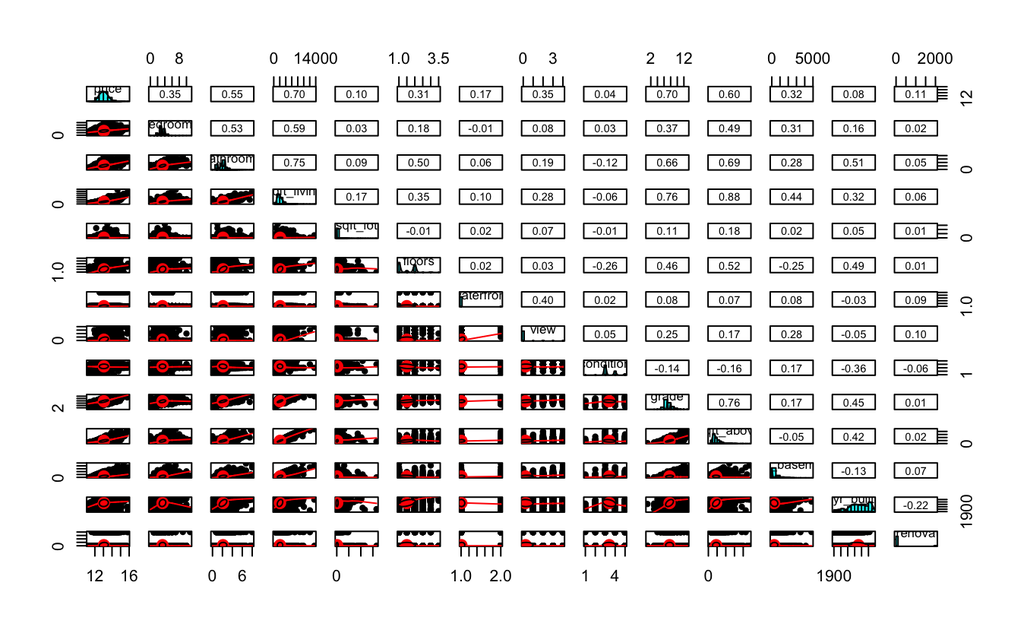

```r
pairs.panels(kc_house_log)
```

model 1

```r
house.glm1 <- glm(price ~ bedrooms+bathrooms+sqft_living+sqft_lot+floors+waterfront+view+condition+grade+sqft_above+sqft_basement+yr_built+yr_renovated, data = kc_house_log)
```

### Step 5.2 : Evaluating the model - log(price) and using all variables

```r
summary(house.glm1)
```

```
Call:
glm(formula = price ~ bedrooms + bathrooms + sqft_living + sqft_lot +
    floors + waterfront + view + condition + grade + sqft_above +
    sqft_basement + yr_built + yr_renovated, data = kc_house_log)

Deviance Residuals:
     Min        1Q    Median        3Q       Max
-1.87591  -0.21125   0.01574   0.21034   1.40554

Coefficients: (1 not defined because of singularities)
                Estimate Std. Error t value Pr(>|t|)
(Intercept)    2.115e+01  2.001e-01 105.713   <2e-16 ***
bedrooms      -2.540e-02  3.054e-03  -8.318   <2e-16 ***
bathrooms      7.598e-02  5.062e-03  15.008   <2e-16 ***
sqft_living    2.140e-04  6.674e-06  32.064   <2e-16 ***
sqft_lot      -2.477e-08  5.298e-08  -0.467   0.6402
floors         1.044e-01  5.406e-03  19.307   <2e-16 ***
waterfront1    3.309e-01  2.698e-02  12.264   <2e-16 ***
view           4.709e-02  3.264e-03  14.426   <2e-16 ***
condition      4.089e-02  3.615e-03  11.311   <2e-16 ***
grade          2.271e-01  3.135e-03  72.434   <2e-16 ***
sqft_above    -6.335e-05  6.446e-06  -9.829   <2e-16 ***
sqft_basement         NA         NA      NA       NA
yr_built      -5.358e-03  1.025e-04 -52.252   <2e-16 ***
yr_renovated   9.325e-06  5.664e-06   1.646   0.0997 .
---
Signif. codes:  0 ‘***’ 0.001 ‘**’ 0.01 ‘*’ 0.05 ‘.’ 0.1 ‘ ’ 1

(Dispersion parameter for gaussian family taken to be 0.09799911)

    Null deviance: 5995.0  on 21611  degrees of freedom
Residual deviance: 2116.7  on 21599  degrees of freedom
AIC: 11147

Number of Fisher Scoring iterations: 2
```

### Step 6.2 : Improving the model - log(price) and using all variables

#### 1) Adding all the possible relation to the model

model 2

```r
house.glm2 <- update(house.glm1, ~ . - sqft_basement)
summary(house.glm2)
```

```
Call:
glm(formula = price ~ bedrooms + bathrooms + sqft_living + sqft_lot +
    floors + waterfront + view + condition + grade + sqft_above +
    yr_built + yr_renovated, data = kc_house_log)

Deviance Residuals:
     Min        1Q    Median        3Q       Max
-1.87591  -0.21125   0.01574   0.21034   1.40554

Coefficients:
               Estimate Std. Error t value Pr(>|t|)
(Intercept)   2.115e+01  2.001e-01 105.713   <2e-16 ***
bedrooms     -2.540e-02  3.054e-03  -8.318   <2e-16 ***
bathrooms     7.598e-02  5.062e-03  15.008   <2e-16 ***
sqft_living   2.140e-04  6.674e-06  32.064   <2e-16 ***
sqft_lot     -2.477e-08  5.298e-08  -0.467   0.6402
floors        1.044e-01  5.406e-03  19.307   <2e-16 ***
waterfront1   3.309e-01  2.698e-02  12.264   <2e-16 ***
view          4.709e-02  3.264e-03  14.426   <2e-16 ***
condition     4.089e-02  3.615e-03  11.311   <2e-16 ***
grade         2.271e-01  3.135e-03  72.434   <2e-16 ***
sqft_above   -6.335e-05  6.446e-06  -9.829   <2e-16 ***
yr_built     -5.358e-03  1.025e-04 -52.252   <2e-16 ***
yr_renovated  9.325e-06  5.664e-06   1.646   0.0997 .
---
Signif. codes:  0 ‘***’ 0.001 ‘**’ 0.01 ‘*’ 0.05 ‘.’ 0.1 ‘ ’ 1

(Dispersion parameter for gaussian family taken to be 0.09799911)

    Null deviance: 5995.0  on 21611  degrees of freedom
Residual deviance: 2116.7  on 21599  degrees of freedom
AIC: 11147

Number of Fisher Scoring iterations: 2
```

model 3

```r
house.glm3 <- update(house.glm2, ~ . - sqft_lot)
summary(house.glm3)
```

```
Call:
glm(formula = price ~ bedrooms + bathrooms + sqft_living + floors +
    waterfront + view + condition + grade + sqft_above + yr_built +
    yr_renovated, data = kc_house_log)

Deviance Residuals:
     Min        1Q    Median        3Q       Max
-1.88039  -0.21112   0.01575   0.21031   1.40560

Coefficients:
               Estimate Std. Error t value Pr(>|t|)
(Intercept)   2.116e+01  2.001e-01 105.755   <2e-16 ***
bedrooms     -2.529e-02  3.044e-03  -8.308   <2e-16 ***
bathrooms     7.602e-02  5.062e-03  15.018   <2e-16 ***
sqft_living   2.139e-04  6.670e-06  32.068   <2e-16 ***
floors        1.046e-01  5.378e-03  19.455   <2e-16 ***
waterfront1   3.311e-01  2.698e-02  12.272   <2e-16 ***
view          4.703e-02  3.261e-03  14.419   <2e-16 ***
condition     4.088e-02  3.615e-03  11.308   <2e-16 ***
grade         2.271e-01  3.131e-03  72.533   <2e-16 ***
sqft_above   -6.369e-05  6.405e-06  -9.945   <2e-16 ***
yr_built     -5.360e-03  1.025e-04 -52.296   <2e-16 ***
yr_renovated  9.303e-06  5.664e-06   1.643      0.1
---
Signif. codes:  0 ‘***’ 0.001 ‘**’ 0.01 ‘*’ 0.05 ‘.’ 0.1 ‘ ’ 1

(Dispersion parameter for gaussian family taken to be 0.09799556)

    Null deviance: 5995.0  on 21611  degrees of freedom
Residual deviance: 2116.7  on 21600  degrees of freedom
AIC: 11145

Number of Fisher Scoring iterations: 2
```

model 4

```r
house.glm4 <- update(house.glm3, ~ . - yr_renovated)
summary(house.glm4)
```

```
Call:
glm(formula = price ~ bedrooms + bathrooms + sqft_living + floors +
    waterfront + view + condition + grade + sqft_above + yr_built,
    data = kc_house_log)

Deviance Residuals:
     Min        1Q    Median        3Q       Max
-1.88657  -0.21126   0.01605   0.21025   1.40499

Coefficients:
              Estimate Std. Error t value Pr(>|t|)
(Intercept)  2.126e+01  1.891e-01 112.472   <2e-16 ***
bedrooms    -2.544e-02  3.042e-03  -8.363   <2e-16 ***
bathrooms    7.712e-02  5.017e-03  15.372   <2e-16 ***
sqft_living  2.138e-04  6.670e-06  32.056   <2e-16 ***
floors       1.050e-01  5.373e-03  19.546   <2e-16 ***
waterfront1  3.337e-01  2.694e-02  12.386   <2e-16 ***
view         4.715e-02  3.261e-03  14.459   <2e-16 ***
condition    3.991e-02  3.566e-03  11.190   <2e-16 ***
grade        2.272e-01  3.131e-03  72.548   <2e-16 ***
sqft_above  -6.367e-05  6.405e-06  -9.940   <2e-16 ***
yr_built    -5.414e-03  9.712e-05 -55.741   <2e-16 ***
---
Signif. codes:  0 ‘***’ 0.001 ‘**’ 0.01 ‘*’ 0.05 ‘.’ 0.1 ‘ ’ 1

(Dispersion parameter for gaussian family taken to be 0.09800327)

    Null deviance: 5995  on 21611  degrees of freedom
Residual deviance: 2117  on 21601  degrees of freedom
AIC: 11146

Number of Fisher Scoring iterations: 2
```

adding interaction by checking the graph model 5 - sqft_living interaction

```r
house.glm5 <- update(house.glm4, ~ . + sqft_above:sqft_living + grade:sqft_living + bathrooms:sqft_living + floors:sqft_living + view:sqft_living)
summary(house.glm5)
```

```
Call:
glm(formula = price ~ bedrooms + bathrooms + sqft_living + floors +
    waterfront + view + condition + grade + sqft_above + yr_built +
    sqft_living:sqft_above + sqft_living:grade + bathrooms:sqft_living +
    sqft_living:floors + sqft_living:view, data = kc_house_log)

Deviance Residuals:
     Min        1Q    Median        3Q       Max
-1.33853  -0.20881   0.01564   0.20800   1.44116

Coefficients:
                         Estimate Std. Error t value Pr(>|t|)
(Intercept)             2.135e+01  1.914e-01 111.534  < 2e-16 ***
bedrooms               -3.738e-02  3.144e-03 -11.889  < 2e-16 ***
bathrooms               7.743e-02  9.722e-03   7.964 1.74e-15 ***
sqft_living             4.128e-04  1.799e-05  22.947  < 2e-16 ***
floors                  1.400e-01  1.250e-02  11.204  < 2e-16 ***
waterfront1             3.507e-01  2.682e-02  13.076  < 2e-16 ***
view                    8.881e-02  7.575e-03  11.723  < 2e-16 ***
condition               3.644e-02  3.556e-03  10.248  < 2e-16 ***
grade                   2.687e-01  6.840e-03  39.289  < 2e-16 ***
sqft_above             -6.156e-05  1.094e-05  -5.627 1.86e-08 ***
yr_built               -5.640e-03  9.883e-05 -57.067  < 2e-16 ***
sqft_living:sqft_above  7.185e-09  3.254e-09   2.208   0.0273 *
sqft_living:grade      -1.937e-05  2.564e-06  -7.555 4.36e-14 ***
bathrooms:sqft_living  -1.711e-06  3.546e-06  -0.483   0.6294
sqft_living:floors     -2.326e-05  5.885e-06  -3.952 7.78e-05 ***
sqft_living:view       -1.399e-05  2.462e-06  -5.684 1.34e-08 ***
---
Signif. codes:  0 ‘***’ 0.001 ‘**’ 0.01 ‘*’ 0.05 ‘.’ 0.1 ‘ ’ 1

(Dispersion parameter for gaussian family taken to be 0.09670111)

    Null deviance: 5995.0  on 21611  degrees of freedom
Residual deviance: 2088.4  on 21596  degrees of freedom
AIC: 10862

Number of Fisher Scoring iterations: 2
```

model 6

```r
house.glm6 <- update(house.glm5, ~ . - bathrooms:sqft_living)
summary(house.glm6)
```

```
Call:
glm(formula = price ~ bedrooms + bathrooms + sqft_living + floors +
    waterfront + view + condition + grade + sqft_above + yr_built +
    sqft_living:sqft_above + sqft_living:grade + sqft_living:floors +
    sqft_living:view, data = kc_house_log)

Deviance Residuals:
     Min        1Q    Median        3Q       Max
-1.35766  -0.20882   0.01566   0.20816   1.44067

Coefficients:
                         Estimate Std. Error t value Pr(>|t|)
(Intercept)             2.134e+01  1.899e-01 112.375  < 2e-16 ***
bedrooms               -3.745e-02  3.141e-03 -11.925  < 2e-16 ***
bathrooms               7.341e-02  4.993e-03  14.702  < 2e-16 ***
sqft_living             4.135e-04  1.794e-05  23.046  < 2e-16 ***
floors                  1.407e-01  1.241e-02  11.345  < 2e-16 ***
waterfront1             3.509e-01  2.681e-02  13.086  < 2e-16 ***
view                    8.918e-02  7.537e-03  11.832  < 2e-16 ***
condition               3.654e-02  3.551e-03  10.288  < 2e-16 ***
grade                   2.695e-01  6.625e-03  40.684  < 2e-16 ***
sqft_above             -5.923e-05  9.821e-06  -6.031 1.65e-09 ***
yr_built               -5.636e-03  9.839e-05 -57.277  < 2e-16 ***
sqft_living:sqft_above  6.356e-09  2.764e-09   2.300   0.0215 *
sqft_living:grade      -1.969e-05  2.475e-06  -7.955 1.88e-15 ***
sqft_living:floors     -2.356e-05  5.851e-06  -4.026 5.69e-05 ***
sqft_living:view       -1.414e-05  2.441e-06  -5.794 6.95e-09 ***
---
Signif. codes:  0 ‘***’ 0.001 ‘**’ 0.01 ‘*’ 0.05 ‘.’ 0.1 ‘ ’ 1

(Dispersion parameter for gaussian family taken to be 0.09669768)

    Null deviance: 5995.0  on 21611  degrees of freedom
Residual deviance: 2088.4  on 21597  degrees of freedom
AIC: 10860

Number of Fisher Scoring iterations: 2
```

model 7 - bedrooms interaction

```r
house.glm7 <- update(house.glm6, ~ . + bedrooms:bathrooms + bedrooms:grade + bedrooms:sqft_above)
summary(house.glm7)
```

```
Call:
glm(formula = price ~ bedrooms + bathrooms + sqft_living + floors +
    waterfront + view + condition + grade + sqft_above + yr_built +
    sqft_living:sqft_above + sqft_living:grade + sqft_living:floors +
    sqft_living:view + bedrooms:bathrooms + bedrooms:grade +
    bedrooms:sqft_above, data = kc_house_log)

Deviance Residuals:
     Min        1Q    Median        3Q       Max
-1.45149  -0.20796   0.01531   0.20822   1.46309

Coefficients:
                         Estimate Std. Error t value Pr(>|t|)
(Intercept)             2.146e+01  1.950e-01 110.016  < 2e-16 ***
bedrooms               -1.194e-01  2.045e-02  -5.840 5.28e-09 ***
bathrooms               8.171e-02  1.384e-02   5.905 3.58e-09 ***
sqft_living             4.636e-04  2.148e-05  21.586  < 2e-16 ***
floors                  1.490e-01  1.257e-02  11.854  < 2e-16 ***
waterfront1             3.581e-01  2.682e-02  13.352  < 2e-16 ***
view                    8.561e-02  7.552e-03  11.336  < 2e-16 ***
condition               3.716e-02  3.556e-03  10.451  < 2e-16 ***
grade                   2.525e-01  9.858e-03  25.609  < 2e-16 ***
sqft_above             -9.869e-05  1.768e-05  -5.584 2.38e-08 ***
yr_built               -5.614e-03  9.873e-05 -56.860  < 2e-16 ***
sqft_living:sqft_above  4.101e-09  3.383e-09   1.212   0.2253
sqft_living:grade      -2.439e-05  3.064e-06  -7.958 1.83e-15 ***
sqft_living:floors     -2.896e-05  5.937e-06  -4.877 1.08e-06 ***
sqft_living:view       -1.286e-05  2.449e-06  -5.250 1.53e-07 ***
bedrooms:bathrooms     -2.705e-03  3.568e-03  -0.758   0.4483
bedrooms:grade          8.495e-03  3.328e-03   2.553   0.0107 *
bedrooms:sqft_above     1.290e-05  5.195e-06   2.483   0.0130 *
---
Signif. codes:  0 ‘***’ 0.001 ‘**’ 0.01 ‘*’ 0.05 ‘.’ 0.1 ‘ ’ 1

(Dispersion parameter for gaussian family taken to be 0.09653253)

    Null deviance: 5995.0  on 21611  degrees of freedom
Residual deviance: 2084.5  on 21594  degrees of freedom
AIC: 10826

Number of Fisher Scoring iterations: 2
```

model 8

```r
house.glm8 <- update(house.glm7, ~ . - bedrooms:sqft_above - bedrooms:bathrooms - sqft_living:sqft_above)
summary(house.glm8)
```

```
Call:
glm(formula = price ~ bedrooms + bathrooms + sqft_living + floors +
    waterfront + view + condition + grade + sqft_above + yr_built +
    sqft_living:grade + sqft_living:floors + sqft_living:view +
    bedrooms:grade, data = kc_house_log)

Deviance Residuals:
     Min        1Q    Median        3Q       Max
-1.40764  -0.20845   0.01571   0.20891   1.45979

Coefficients:
                     Estimate Std. Error t value Pr(>|t|)
(Intercept)         2.156e+01  1.917e-01 112.486  < 2e-16 ***
bedrooms           -1.339e-01  1.813e-02  -7.387 1.56e-13 ***
bathrooms           7.307e-02  4.988e-03  14.650  < 2e-16 ***
sqft_living         4.382e-04  1.718e-05  25.507  < 2e-16 ***
floors              1.406e-01  1.217e-02  11.548  < 2e-16 ***
waterfront1         3.577e-01  2.683e-02  13.334  < 2e-16 ***
view                8.186e-02  7.445e-03  10.996  < 2e-16 ***
condition           3.700e-02  3.550e-03  10.420  < 2e-16 ***
grade               2.303e-01  7.470e-03  30.833  < 2e-16 ***
sqft_above         -4.176e-05  7.010e-06  -5.958 2.59e-09 ***
yr_built           -5.613e-03  9.835e-05 -57.073  < 2e-16 ***
sqft_living:grade  -2.131e-05  2.038e-06 -10.452  < 2e-16 ***
sqft_living:floors -2.374e-05  5.716e-06  -4.153 3.30e-05 ***
sqft_living:view   -1.171e-05  2.419e-06  -4.840 1.31e-06 ***
bedrooms:grade      1.264e-02  2.352e-03   5.375 7.73e-08 ***
---
Signif. codes:  0 ‘***’ 0.001 ‘**’ 0.01 ‘*’ 0.05 ‘.’ 0.1 ‘ ’ 1

(Dispersion parameter for gaussian family taken to be 0.09659214)

    Null deviance: 5995.0  on 21611  degrees of freedom
Residual deviance: 2086.1  on 21597  degrees of freedom
AIC: 10836

Number of Fisher Scoring iterations: 2
```

model 9 - bathrooms interaction

```r
house.glm9 <- update(house.glm8, ~ . + bathrooms:floors + bathrooms:grade + bathrooms:sqft_above)
summary(house.glm9)
```

```
Call:
glm(formula = price ~ bedrooms + bathrooms + sqft_living + floors +
    waterfront + view + condition + grade + sqft_above + yr_built +
    sqft_living:grade + sqft_living:floors + sqft_living:view +
    bedrooms:grade + bathrooms:floors + bathrooms:grade + bathrooms:sqft_above,
    data = kc_house_log)

Deviance Residuals:
     Min        1Q    Median        3Q       Max
-1.47519  -0.20813   0.01544   0.20881   1.46039

Coefficients:
                       Estimate Std. Error t value Pr(>|t|)
(Intercept)           2.147e+01  1.950e-01 110.117  < 2e-16 ***
bedrooms             -1.303e-01  1.863e-02  -6.993 2.77e-12 ***
bathrooms             3.940e-02  2.954e-02   1.334  0.18231
sqft_living           4.812e-04  2.443e-05  19.692  < 2e-16 ***
floors                1.600e-01  1.742e-02   9.184  < 2e-16 ***
waterfront1           3.588e-01  2.683e-02  13.372  < 2e-16 ***
view                  8.346e-02  7.515e-03  11.105  < 2e-16 ***
condition             3.747e-02  3.556e-03  10.536  < 2e-16 ***
grade                 2.372e-01  9.079e-03  26.126  < 2e-16 ***
sqft_above           -6.568e-05  1.243e-05  -5.282 1.29e-07 ***
yr_built             -5.586e-03  9.902e-05 -56.418  < 2e-16 ***
sqft_living:grade    -2.675e-05  2.994e-06  -8.933  < 2e-16 ***
sqft_living:floors   -2.345e-05  7.198e-06  -3.258  0.00113 **
sqft_living:view     -1.216e-05  2.440e-06  -4.983 6.31e-07 ***
bedrooms:grade        1.217e-02  2.419e-03   5.030 4.93e-07 ***
bathrooms:floors     -8.550e-03  8.956e-03  -0.955  0.33978
bathrooms:grade       3.518e-03  4.219e-03   0.834  0.40440
bathrooms:sqft_above  9.654e-06  4.167e-06   2.317  0.02051 *
---
Signif. codes:  0 ‘***’ 0.001 ‘**’ 0.01 ‘*’ 0.05 ‘.’ 0.1 ‘ ’ 1

(Dispersion parameter for gaussian family taken to be 0.09656421)

    Null deviance: 5995.0  on 21611  degrees of freedom
Residual deviance: 2085.2  on 21594  degrees of freedom
AIC: 10833

Number of Fisher Scoring iterations: 2
```

model 10

```r
house.glm10 <- update(house.glm9, ~ . - bathrooms:grade - bathrooms:floors)
summary(house.glm10)
```

```
Call:
glm(formula = price ~ bedrooms + bathrooms + sqft_living + floors +
    waterfront + view + condition + grade + sqft_above + yr_built +
    sqft_living:grade + sqft_living:floors + sqft_living:view +
    bedrooms:grade + bathrooms:sqft_above, data = kc_house_log)

Deviance Residuals:
    Min       1Q   Median       3Q      Max
-1.4698  -0.2079   0.0157   0.2086   1.4617

Coefficients:
                       Estimate Std. Error t value Pr(>|t|)
(Intercept)           2.148e+01  1.936e-01 110.978  < 2e-16 ***
bedrooms             -1.326e-01  1.814e-02  -7.311 2.75e-13 ***
bathrooms             5.280e-02  8.744e-03   6.038 1.58e-09 ***
sqft_living           4.744e-04  2.142e-05  22.141  < 2e-16 ***
floors                1.492e-01  1.255e-02  11.890  < 2e-16 ***
waterfront1           3.586e-01  2.683e-02  13.368  < 2e-16 ***
view                  8.374e-02  7.474e-03  11.205  < 2e-16 ***
condition             3.746e-02  3.554e-03  10.541  < 2e-16 ***
grade                 2.401e-01  8.239e-03  29.148  < 2e-16 ***
sqft_above           -6.602e-05  1.109e-05  -5.953 2.67e-09 ***
yr_built             -5.598e-03  9.850e-05 -56.830  < 2e-16 ***
sqft_living:grade    -2.505e-05  2.432e-06 -10.301  < 2e-16 ***
sqft_living:floors   -2.767e-05  5.883e-06  -4.704 2.57e-06 ***
sqft_living:view     -1.228e-05  2.427e-06  -5.059 4.25e-07 ***
bedrooms:grade        1.249e-02  2.352e-03   5.309 1.11e-07 ***
bathrooms:sqft_above  1.008e-05  3.571e-06   2.822  0.00477 **
---
Signif. codes:  0 ‘***’ 0.001 ‘**’ 0.01 ‘*’ 0.05 ‘.’ 0.1 ‘ ’ 1

(Dispersion parameter for gaussian family taken to be 0.096561)

    Null deviance: 5995.0  on 21611  degrees of freedom
Residual deviance: 2085.3  on 21596  degrees of freedom
AIC: 10830

Number of Fisher Scoring iterations: 2
```

model 11 - floors interaction

```r
house.glm11 <- update(house.glm10, ~ . + floors:condition + floors:grade + floors:sqft_above)
summary(house.glm11)
```

```
Call:
glm(formula = price ~ bedrooms + bathrooms + sqft_living + floors +
    waterfront + view + condition + grade + sqft_above + yr_built +
    sqft_living:grade + sqft_living:floors + sqft_living:view +
    bedrooms:grade + bathrooms:sqft_above + floors:condition +
    floors:grade + floors:sqft_above, data = kc_house_log)

Deviance Residuals:
     Min        1Q    Median        3Q       Max
-1.49751  -0.20760   0.01532   0.20902   1.45728

Coefficients:
                       Estimate Std. Error t value Pr(>|t|)
(Intercept)           2.150e+01  2.003e-01 107.308  < 2e-16 ***
bedrooms             -1.335e-01  1.815e-02  -7.353 2.00e-13 ***
bathrooms             4.978e-02  8.909e-03   5.588 2.33e-08 ***
sqft_living           4.579e-04  2.544e-05  18.001  < 2e-16 ***
floors                1.681e-01  4.813e-02   3.492  0.00048 ***
waterfront1           3.596e-01  2.684e-02  13.398  < 2e-16 ***
view                  8.456e-02  7.532e-03  11.227  < 2e-16 ***
condition             5.454e-02  1.076e-02   5.071 4.00e-07 ***
grade                 2.328e-01  1.122e-02  20.754  < 2e-16 ***
sqft_above           -1.700e-05  2.209e-05  -0.769  0.44168
yr_built             -5.618e-03  1.026e-04 -54.784  < 2e-16 ***
sqft_living:grade    -2.616e-05  2.522e-06 -10.373  < 2e-16 ***
sqft_living:floors   -7.647e-06  1.110e-05  -0.689  0.49084
sqft_living:view     -1.264e-05  2.462e-06  -5.133 2.88e-07 ***
bedrooms:grade        1.265e-02  2.354e-03   5.371 7.89e-08 ***
bathrooms:sqft_above  1.114e-05  3.645e-06   3.056  0.00225 **
floors:condition     -1.342e-02  7.939e-03  -1.690  0.09106 .
floors:grade          5.697e-03  5.806e-03   0.981  0.32646
floors:sqft_above    -3.428e-05  1.373e-05  -2.496  0.01257 *
---
Signif. codes:  0 ‘***’ 0.001 ‘**’ 0.01 ‘*’ 0.05 ‘.’ 0.1 ‘ ’ 1

(Dispersion parameter for gaussian family taken to be 0.09653497)

    Null deviance: 5995.0  on 21611  degrees of freedom
Residual deviance: 2084.5  on 21593  degrees of freedom
AIC: 10828

Number of Fisher Scoring iterations: 2
```

model 12

```r
house.glm12 <- update(house.glm11, ~ . - sqft_living:floors - floors:condition -floors:grade)
summary(house.glm12)
```

```
Call:
glm(formula = price ~ bedrooms + bathrooms + sqft_living + floors +
    waterfront + view + condition + grade + sqft_above + yr_built +
    sqft_living:grade + sqft_living:view + bedrooms:grade + bathrooms:sqft_above +
    floors:sqft_above, data = kc_house_log)

Deviance Residuals:
     Min        1Q    Median        3Q       Max
-1.49791  -0.20771   0.01574   0.20874   1.45809

Coefficients:
                       Estimate Std. Error t value Pr(>|t|)
(Intercept)           2.140e+01  1.929e-01 110.923  < 2e-16 ***
bedrooms             -1.330e-01  1.813e-02  -7.337 2.26e-13 ***
bathrooms             4.979e-02  8.848e-03   5.628 1.85e-08 ***
sqft_living           4.431e-04  2.070e-05  21.404  < 2e-16 ***
floors                1.586e-01  1.340e-02  11.832  < 2e-16 ***
waterfront1           3.606e-01  2.683e-02  13.444  < 2e-16 ***
view                  8.583e-02  7.485e-03  11.467  < 2e-16 ***
condition             3.743e-02  3.553e-03  10.535  < 2e-16 ***
grade                 2.409e-01  8.187e-03  29.428  < 2e-16 ***
sqft_above           -1.488e-05  1.518e-05  -0.980  0.32720
yr_built             -5.564e-03  9.807e-05 -56.732  < 2e-16 ***
sqft_living:grade    -2.563e-05  2.418e-06 -10.600  < 2e-16 ***
sqft_living:view     -1.320e-05  2.435e-06  -5.419 6.05e-08 ***
bedrooms:grade        1.259e-02  2.352e-03   5.353 8.73e-08 ***
bathrooms:sqft_above  1.096e-05  3.598e-06   3.048  0.00231 **
floors:sqft_above    -3.718e-05  7.278e-06  -5.109 3.27e-07 ***
---
Signif. codes:  0 ‘***’ 0.001 ‘**’ 0.01 ‘*’ 0.05 ‘.’ 0.1 ‘ ’ 1

(Dispersion parameter for gaussian family taken to be 0.09654325)

    Null deviance: 5995.0  on 21611  degrees of freedom
Residual deviance: 2084.9  on 21596  degrees of freedom
AIC: 10826

Number of Fisher Scoring iterations: 2
```

model 13

```r
house.glm13 <- update(house.glm12, ~ . - sqft_above)
summary(house.glm13)
```

```
Call:
glm(formula = price ~ bedrooms + bathrooms + sqft_living + floors +
    waterfront + view + condition + grade + yr_built + sqft_living:grade +
    sqft_living:view + bedrooms:grade + bathrooms:sqft_above +
    floors:sqft_above, data = kc_house_log)

Deviance Residuals:
     Min        1Q    Median        3Q       Max
-1.49100  -0.20763   0.01565   0.20880   1.45695

Coefficients:
                       Estimate Std. Error t value Pr(>|t|)
(Intercept)           2.143e+01  1.908e-01 112.317  < 2e-16 ***
bedrooms             -1.348e-01  1.804e-02  -7.472 8.20e-14 ***
bathrooms             5.262e-02  8.363e-03   6.292 3.19e-10 ***
sqft_living           4.349e-04  1.893e-05  22.976  < 2e-16 ***
floors                1.656e-01  1.130e-02  14.653  < 2e-16 ***
waterfront1           3.602e-01  2.682e-02  13.430  < 2e-16 ***
view                  8.548e-02  7.477e-03  11.433  < 2e-16 ***
condition             3.738e-02  3.553e-03  10.522  < 2e-16 ***
grade                 2.379e-01  7.566e-03  31.438  < 2e-16 ***
yr_built             -5.576e-03  9.729e-05 -57.310  < 2e-16 ***
sqft_living:grade    -2.485e-05  2.282e-06 -10.889  < 2e-16 ***
sqft_living:view     -1.304e-05  2.430e-06  -5.368 8.05e-08 ***
bedrooms:grade        1.282e-02  2.340e-03   5.479 4.33e-08 ***
bathrooms:sqft_above  9.601e-06  3.317e-06   2.894  0.00381 **
floors:sqft_above    -4.206e-05  5.312e-06  -7.917 2.55e-15 ***
---
Signif. codes:  0 ‘***’ 0.001 ‘**’ 0.01 ‘*’ 0.05 ‘.’ 0.1 ‘ ’ 1

(Dispersion parameter for gaussian family taken to be 0.09654307)

    Null deviance: 5995  on 21611  degrees of freedom
Residual deviance: 2085  on 21597  degrees of freedom
AIC: 10825

Number of Fisher Scoring iterations: 2
```

```r
house.glm14 <- update(house.glm13, ~ . + waterfront:view + view:grade + grade:sqft_above)
summary(house.glm14)
```

```
Call:
glm(formula = price ~ bedrooms + bathrooms + sqft_living + floors +
    waterfront + view + condition + grade + yr_built + sqft_living:grade +
    sqft_living:view + bedrooms:grade + bathrooms:sqft_above +
    floors:sqft_above + waterfront:view + view:grade + grade:sqft_above,
    data = kc_house_log)

Deviance Residuals:
     Min        1Q    Median        3Q       Max
-1.48332  -0.20768   0.01546   0.20860   1.45654

Coefficients:
                       Estimate Std. Error t value Pr(>|t|)
(Intercept)           2.144e+01  1.927e-01 111.278  < 2e-16 ***
bedrooms             -1.364e-01  1.824e-02  -7.478 7.86e-14 ***
bathrooms             5.343e-02  8.935e-03   5.980 2.26e-09 ***
sqft_living           4.380e-04  1.963e-05  22.311  < 2e-16 ***
floors                1.704e-01  1.412e-02  12.070  < 2e-16 ***
waterfront1           7.505e-02  1.658e-01   0.453   0.6508
view                  7.839e-02  1.995e-02   3.929 8.57e-05 ***
condition             3.747e-02  3.554e-03  10.541  < 2e-16 ***
grade                 2.356e-01  8.512e-03  27.678  < 2e-16 ***
yr_built             -5.581e-03  9.780e-05 -57.068  < 2e-16 ***
sqft_living:grade    -2.527e-05  2.406e-06 -10.503  < 2e-16 ***
sqft_living:view     -1.405e-05  3.593e-06  -3.912 9.20e-05 ***
bedrooms:grade        1.303e-02  2.367e-03   5.502 3.79e-08 ***
bathrooms:sqft_above  9.179e-06  3.664e-06   2.505   0.0122 *
floors:sqft_above    -4.509e-05  7.660e-06  -5.886 4.02e-09 ***
waterfront1:view      7.613e-02  4.365e-02   1.744   0.0812 .
view:grade            1.132e-03  3.026e-03   0.374   0.7084
grade:sqft_above      9.250e-07  1.930e-06   0.479   0.6317
---
Signif. codes:  0 ‘***’ 0.001 ‘**’ 0.01 ‘*’ 0.05 ‘.’ 0.1 ‘ ’ 1

(Dispersion parameter for gaussian family taken to be 0.09654095)

    Null deviance: 5995.0  on 21611  degrees of freedom
Residual deviance: 2084.7  on 21594  degrees of freedom
AIC: 10828

Number of Fisher Scoring iterations: 2
```

model 15

```r
house.glm15 <- update(house.glm14, ~ . - grade:sqft_above - view:grade - waterfront)
summary(house.glm15)
```

```
Call:
glm(formula = price ~ bedrooms + bathrooms + sqft_living + floors +
    view + condition + grade + yr_built + sqft_living:grade +
    sqft_living:view + bedrooms:grade + bathrooms:sqft_above +
    floors:sqft_above + waterfront:view, data = kc_house_log)

Deviance Residuals:
     Min        1Q    Median        3Q       Max
-1.48990  -0.20775   0.01554   0.20877   1.45692

Coefficients:
                       Estimate Std. Error t value Pr(>|t|)
(Intercept)           2.143e+01  1.908e-01 112.345  < 2e-16 ***
bedrooms             -1.347e-01  1.804e-02  -7.465 8.61e-14 ***
bathrooms             5.239e-02  8.363e-03   6.265 3.81e-10 ***
sqft_living           4.347e-04  1.892e-05  22.968  < 2e-16 ***
floors                1.660e-01  1.130e-02  14.681  < 2e-16 ***
view                  8.587e-02  7.472e-03  11.492  < 2e-16 ***
condition             3.751e-02  3.553e-03  10.558  < 2e-16 ***
grade                 2.378e-01  7.565e-03  31.433  < 2e-16 ***
yr_built             -5.578e-03  9.729e-05 -57.335  < 2e-16 ***
sqft_living:grade    -2.479e-05  2.282e-06 -10.864  < 2e-16 ***
sqft_living:view     -1.333e-05  2.431e-06  -5.484 4.20e-08 ***
bedrooms:grade        1.279e-02  2.340e-03   5.467 4.64e-08 ***
bathrooms:sqft_above  9.689e-06  3.317e-06   2.921   0.0035 **
floors:sqft_above    -4.221e-05  5.312e-06  -7.947 2.01e-15 ***
view:waterfront1      9.560e-02  7.062e-03  13.538  < 2e-16 ***
---
Signif. codes:  0 ‘***’ 0.001 ‘**’ 0.01 ‘*’ 0.05 ‘.’ 0.1 ‘ ’ 1

(Dispersion parameter for gaussian family taken to be 0.09653019)

    Null deviance: 5995.0  on 21611  degrees of freedom
Residual deviance: 2084.8  on 21597  degrees of freedom
AIC: 10823

Number of Fisher Scoring iterations: 2
```

#### 2) as per concept of parsimony : checking best fit from above model

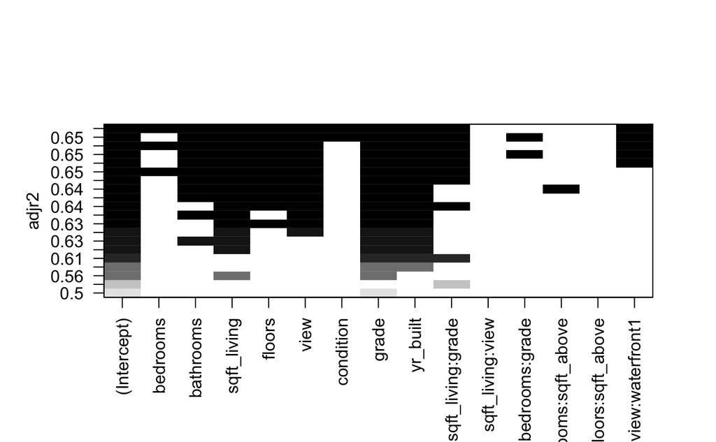

```r
house.glm15.bestFit1 <- regsubsets(price ~ bedrooms + bathrooms + sqft_living + floors +
                                  view + condition + grade + yr_built + sqft_living:grade +
                                  sqft_living:view + bedrooms:grade + bathrooms:sqft_above +
                                  floors:sqft_above + waterfront:view, data = kc_house_log, nbest = 2, nvmax = 10)
par(mfrow = c(1,1))
#subsets(house.glm15.bestFit1, statistic = "adjr2")
plot(house.glm15.bestFit1, scale = "adjr2")
```

from above we can see 4,5,6 and later produce almost similar result

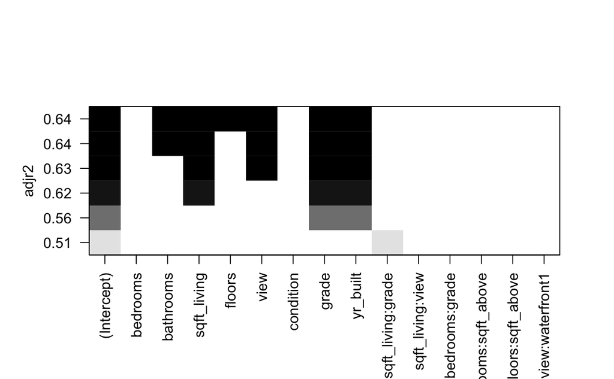

```r
house.glm15.bestFit2 <- regsubsets(price ~ bedrooms + bathrooms + sqft_living + floors +
                                     view + condition + grade + yr_built + sqft_living:grade +
                                     sqft_living:view + bedrooms:grade + bathrooms:sqft_above +
                                     floors:sqft_above + waterfront:view, data = kc_house_log, nbest = 1, nvmax = 6)
par(mfrow = c(1,1))
#subsets(house.glm15.bestFit2, statistic = "adjr2", max.size = 6, min.size = 1)
plot(house.glm15.bestFit2, scale = "adjr2")
```

Doing cross-validation for 3,4,5,6 predictors using K-Fold 3 predictors predictor : 3-i

```r
house.k10.3i <- glm(price ~ sqft_living + grade + yr_built, data = kc_house_log)
summary(house.k10.3i) # 12786
```

```
Call:
glm(formula = price ~ sqft_living + grade + yr_built, data = kc_house_log)

Deviance Residuals:
     Min        1Q    Median        3Q       Max
-1.73279  -0.21945   0.01622   0.21898   1.34761

Coefficients:
              Estimate Std. Error t value Pr(>|t|)
(Intercept)  2.068e+01  1.594e-01  129.70   <2e-16 ***
sqft_living  2.087e-04  3.727e-06   56.00   <2e-16 ***
grade        2.473e-01  3.086e-03   80.14   <2e-16 ***
yr_built    -5.053e-03  8.426e-05  -59.97   <2e-16 ***
---
Signif. codes:  0 ‘***’ 0.001 ‘**’ 0.01 ‘*’ 0.05 ‘.’ 0.1 ‘ ’ 1

(Dispersion parameter for gaussian family taken to be 0.1057657)

    Null deviance: 5995.0  on 21611  degrees of freedom
Residual deviance: 2285.4  on 21608  degrees of freedom
AIC: 12786

Number of Fisher Scoring iterations: 2
```

```r
house.k10.3i.err <- cv.glm(data = kc_house_log,glmfit = house.k10.3i, K = 10)
round(house.k10.3i.err$delta[1], 4) # 0.1058
```

```
[1] 0.1058
```

predictor : 3-ii

```r
house.k10.3ii <- glm(price ~ sqft_living:grade + grade + yr_built, data = kc_house_log)
summary(house.k10.3ii) # 13539
```

```
Call:
glm(formula = price ~ sqft_living:grade + grade + yr_built, data = kc_house_log)

Deviance Residuals:
     Min        1Q    Median        3Q       Max
-2.14677  -0.22200   0.01861   0.22391   1.45162

Coefficients:
                    Estimate Std. Error t value Pr(>|t|)
(Intercept)        2.061e+01  1.622e-01  127.04   <2e-16 ***
grade              2.226e-01  3.818e-03   58.29   <2e-16 ***
yr_built          -4.870e-03  8.602e-05  -56.62   <2e-16 ***
sqft_living:grade  1.996e-05  4.172e-07   47.84   <2e-16 ***
---
Signif. codes:  0 ‘***’ 0.001 ‘**’ 0.01 ‘*’ 0.05 ‘.’ 0.1 ‘ ’ 1

(Dispersion parameter for gaussian family taken to be 0.1095155)

    Null deviance: 5995.0  on 21611  degrees of freedom
Residual deviance: 2366.4  on 21608  degrees of freedom
AIC: 13539

Number of Fisher Scoring iterations: 2
```

```r
house.k10.3ii.err <- cv.glm(data = kc_house_log,glmfit = house.k10.3ii, K = 10)
round(house.k10.3ii.err$delta[1], 4) # 0.1096
```

```
[1] 0.1096
```

4 predictors predictor : 4-i

```r
house.k10.4i <- glm(price ~ sqft_living + grade + yr_built + view, data = kc_house_log)
summary(house.k10.4i) # 12272
```

```
Call:
glm(formula = price ~ sqft_living + grade + yr_built + view,
    data = kc_house_log)

Deviance Residuals:
     Min        1Q    Median        3Q       Max
-1.82869  -0.21786   0.01813   0.21939   1.28731

Coefficients:
              Estimate Std. Error t value Pr(>|t|)
(Intercept)  2.003e+01  1.601e-01  125.16   <2e-16 ***
sqft_living  1.965e-04  3.722e-06   52.80   <2e-16 ***
grade        2.392e-01  3.071e-03   77.90   <2e-16 ***
yr_built    -4.689e-03  8.477e-05  -55.32   <2e-16 ***
view         6.933e-02  3.034e-03   22.85   <2e-16 ***
---
Signif. codes:  0 ‘***’ 0.001 ‘**’ 0.01 ‘*’ 0.05 ‘.’ 0.1 ‘ ’ 1

(Dispersion parameter for gaussian family taken to be 0.1032754)

    Null deviance: 5995.0  on 21611  degrees of freedom
Residual deviance: 2231.5  on 21607  degrees of freedom
AIC: 12272

Number of Fisher Scoring iterations: 2
```

```r
house.k10.4i.err <- cv.glm(data = kc_house_log,glmfit = house.k10.4i, K = 10)
round(house.k10.4i.err$delta[1], 4) # 0.1033
```

```
[1] 0.1033
```

predictor : 4-ii

```r
house.k10.4ii <- glm(price ~ sqft_living + grade + yr_built + bathrooms, data = kc_house_log)
summary(house.k10.4ii) # 12351
```

```
Call:
glm(formula = price ~ sqft_living + grade + yr_built + bathrooms,
    data = kc_house_log)

Deviance Residuals:
     Min        1Q    Median        3Q       Max
-1.69517  -0.21893   0.01573   0.21689   1.39528

Coefficients:
              Estimate Std. Error t value Pr(>|t|)
(Intercept)  2.207e+01  1.711e-01  128.99   <2e-16 ***
sqft_living  1.573e-04  4.428e-06   35.52   <2e-16 ***
grade        2.422e-01  3.065e-03   79.01   <2e-16 ***
yr_built    -5.790e-03  9.049e-05  -63.99   <2e-16 ***
bathrooms    1.011e-01  4.810e-03   21.02   <2e-16 ***
---
Signif. codes:  0 ‘***’ 0.001 ‘**’ 0.01 ‘*’ 0.05 ‘.’ 0.1 ‘ ’ 1

(Dispersion parameter for gaussian family taken to be 0.1036514)

    Null deviance: 5995.0  on 21611  degrees of freedom
Residual deviance: 2239.6  on 21607  degrees of freedom
AIC: 12351

Number of Fisher Scoring iterations: 2
```

```r
house.k10.4ii.err <- cv.glm(data = kc_house_log,glmfit = house.k10.4ii, K = 10)
round(house.k10.4ii.err$delta[1], 4) # 0.1037
```

```
[1] 0.1037
```

5 predictors predictor : 5-i

```r
house.k10.5i <- glm(price ~ sqft_living + grade + yr_built + view + bathrooms, data = kc_house_log)
summary(house.k10.5i) # 11844
```

```
Call:
glm(formula = price ~ sqft_living + grade + yr_built + view +
    bathrooms, data = kc_house_log)

Deviance Residuals:
     Min        1Q    Median        3Q       Max
-1.79020  -0.21669   0.01738   0.21526   1.33784

Coefficients:
              Estimate Std. Error t value Pr(>|t|)
(Intercept)  2.140e+01  1.716e-01  124.75   <2e-16 ***
sqft_living  1.463e-04  4.403e-06   33.23   <2e-16 ***
grade        2.343e-01  3.049e-03   76.83   <2e-16 ***
yr_built    -5.418e-03  9.093e-05  -59.59   <2e-16 ***
view         6.816e-02  3.005e-03   22.68   <2e-16 ***
bathrooms    9.908e-02  4.754e-03   20.84   <2e-16 ***
---
Signif. codes:  0 ‘***’ 0.001 ‘**’ 0.01 ‘*’ 0.05 ‘.’ 0.1 ‘ ’ 1

(Dispersion parameter for gaussian family taken to be 0.101245)

    Null deviance: 5995.0  on 21611  degrees of freedom
Residual deviance: 2187.5  on 21606  degrees of freedom
AIC: 11844

Number of Fisher Scoring iterations: 2
```

```r
house.k10.5i.err <- cv.glm(data = kc_house_log,glmfit = house.k10.5i, K = 10)
round(house.k10.5i.err$delta[1], 4) # 0.1013
```

```
[1] 0.1013
```

predictor : 5-ii

```r
house.k10.5ii <- glm(price ~ sqft_living + grade + yr_built + view + bathrooms, data = kc_house_log)
summary(house.k10.5ii) # 11844
```

```
Call:
glm(formula = price ~ sqft_living + grade + yr_built + view +
    bathrooms, data = kc_house_log)

Deviance Residuals:
     Min        1Q    Median        3Q       Max
-1.79020  -0.21669   0.01738   0.21526   1.33784

Coefficients:
              Estimate Std. Error t value Pr(>|t|)
(Intercept)  2.140e+01  1.716e-01  124.75   <2e-16 ***
sqft_living  1.463e-04  4.403e-06   33.23   <2e-16 ***
grade        2.343e-01  3.049e-03   76.83   <2e-16 ***
yr_built    -5.418e-03  9.093e-05  -59.59   <2e-16 ***
view         6.816e-02  3.005e-03   22.68   <2e-16 ***
bathrooms    9.908e-02  4.754e-03   20.84   <2e-16 ***
---
Signif. codes:  0 ‘***’ 0.001 ‘**’ 0.01 ‘*’ 0.05 ‘.’ 0.1 ‘ ’ 1

(Dispersion parameter for gaussian family taken to be 0.101245)

    Null deviance: 5995.0  on 21611  degrees of freedom
Residual deviance: 2187.5  on 21606  degrees of freedom
AIC: 11844

Number of Fisher Scoring iterations: 2
```

```r
house.k10.5ii.err <- cv.glm(data = kc_house_log,glmfit = house.k10.5ii, K = 10)
round(house.k10.5ii.err$delta[1], 4) # 0.1013
```

```
[1] 0.1013
```

6 predictors predictor : 6-i

```r
house.k10.6i <- glm(price ~ sqft_living + grade + yr_built + view + bathrooms + floors, data = kc_house_log)
summary(house.k10.6i) # 11587
```

```
Call:
glm(formula = price ~ sqft_living + grade + yr_built + view +
    bathrooms + floors, data = kc_house_log)

Deviance Residuals:
     Min        1Q    Median        3Q       Max
-1.84521  -0.21320   0.01657   0.21441   1.34020

Coefficients:
              Estimate Std. Error t value Pr(>|t|)
(Intercept)  2.212e+01  1.763e-01  125.49   <2e-16 ***
sqft_living  1.538e-04  4.401e-06   34.95   <2e-16 ***
grade        2.249e-01  3.087e-03   72.85   <2e-16 ***
yr_built    -5.796e-03  9.337e-05  -62.07   <2e-16 ***
view         7.025e-02  2.990e-03   23.50   <2e-16 ***
bathrooms    8.078e-02  4.860e-03   16.62   <2e-16 ***
floors       7.971e-02  4.942e-03   16.13   <2e-16 ***
---
Signif. codes:  0 ‘***’ 0.001 ‘**’ 0.01 ‘*’ 0.05 ‘.’ 0.1 ‘ ’ 1

(Dispersion parameter for gaussian family taken to be 0.1000448)

    Null deviance: 5995.0  on 21611  degrees of freedom
Residual deviance: 2161.5  on 21605  degrees of freedom
AIC: 11587

Number of Fisher Scoring iterations: 2
```

```r
house.k10.6i.err <- cv.glm(data = kc_house_log,glmfit = house.k10.6i, K = 10)
round(house.k10.6i.err$delta[1], 4) # 0.1001
```

```
[1] 0.1001
```

predictor : 6-ii

```r
house.k10.6ii <- glm(price ~ sqft_living + grade + yr_built + view + sqft_living:grade + floors, data = kc_house_log)
summary(house.k10.6ii) # 11589
```

```
Call:
glm(formula = price ~ sqft_living + grade + yr_built + view +
    sqft_living:grade + floors, data = kc_house_log)

Deviance Residuals:
     Min        1Q    Median        3Q       Max
-1.31134  -0.21063   0.01459   0.21335   1.33178

Coefficients:
                    Estimate Std. Error t value Pr(>|t|)
(Intercept)        2.119e+01  1.681e-01  125.99   <2e-16 ***
sqft_living        3.881e-04  1.225e-05   31.69   <2e-16 ***
grade              2.787e-01  4.411e-03   63.17   <2e-16 ***
yr_built          -5.510e-03  8.967e-05  -61.45   <2e-16 ***
view               7.464e-02  2.994e-03   24.93   <2e-16 ***
floors             9.287e-02  4.819e-03   19.27   <2e-16 ***
sqft_living:grade -2.237e-05  1.349e-06  -16.58   <2e-16 ***
---
Signif. codes:  0 ‘***’ 0.001 ‘**’ 0.01 ‘*’ 0.05 ‘.’ 0.1 ‘ ’ 1

(Dispersion parameter for gaussian family taken to be 0.100051)

    Null deviance: 5995.0  on 21611  degrees of freedom
Residual deviance: 2161.6  on 21605  degrees of freedom
AIC: 11589

Number of Fisher Scoring iterations: 2
```

```r
house.k10.6ii.err <- cv.glm(data = kc_house_log,glmfit = house.k10.6ii, K = 10)
round(house.k10.6ii.err$delta[1], 4) # 0.1001
```

```
[1] 0.1001
```

Checking the r square and adj. r square values for house.k10.6i model

```r
house.k10.6i.lm <- lm(price ~ sqft_living + grade + yr_built + view + bathrooms + floors, data = kc_house_log)
summary(house.k10.6i.lm)
```

```
Call:
lm(formula = price ~ sqft_living + grade + yr_built + view +
    bathrooms + floors, data = kc_house_log)

Residuals:
     Min       1Q   Median       3Q      Max
-1.84521 -0.21320  0.01657  0.21441  1.34020

Coefficients:
              Estimate Std. Error t value Pr(>|t|)
(Intercept)  2.212e+01  1.763e-01  125.49   <2e-16 ***
sqft_living  1.538e-04  4.401e-06   34.95   <2e-16 ***
grade        2.249e-01  3.087e-03   72.85   <2e-16 ***
yr_built    -5.796e-03  9.337e-05  -62.07   <2e-16 ***
view         7.025e-02  2.990e-03   23.50   <2e-16 ***
bathrooms    8.078e-02  4.860e-03   16.62   <2e-16 ***
floors       7.971e-02  4.942e-03   16.13   <2e-16 ***
---
Signif. codes:  0 ‘***’ 0.001 ‘**’ 0.01 ‘*’ 0.05 ‘.’ 0.1 ‘ ’ 1

Residual standard error: 0.3163 on 21605 degrees of freedom
Multiple R-squared:  0.6395,    Adjusted R-squared:  0.6394
F-statistic:  6386 on 6 and 21605 DF,  p-value: < 2.2e-16
```

[figure not shown]

```r
par(mfrow = c(2,2))
plot(house.k10.4)
```

### Step 3.3 - Data transformation - log(price) conversion and using only numeric type parameters

removing very less correlated variable by creating a new df

```r
house <- kc_house_log
```

```r
house <- house[,-c(5,6,7,8,9,12,13,14)]
```

### Step 4.3 : Training a model on the data - log(price) conversion and using only numeric type parameters

Model the linear model model fit 1

```r
house.fit1 <- lm(price ~ bedrooms*bathrooms*sqft_living*grade*sqft_above, data = house)
```

### Step 5.3 : Evaluating the model - log(price) conversion and using only numeric type parameters

Checking the summary and plot of the model

```r
summary(house.fit1)
```

```
Call:
lm(formula = price ~ bedrooms * bathrooms * sqft_living * grade *
    sqft_above, data = house)

Residuals:
     Min       1Q   Median       3Q      Max
-1.26325 -0.24011  0.00189  0.22829  1.43154

Coefficients:
                                                  Estimate Std. Error t value Pr(>|t|)
(Intercept)                                      1.148e+01  2.331e-01  49.265  < 2e-16
bedrooms                                        -2.793e-01  8.482e-02  -3.292 0.000995
bathrooms                                        4.630e-01  2.202e-01   2.103 0.035498
sqft_living                                      5.994e-05  3.614e-04   0.166 0.868257
grade                                            1.482e-01  3.475e-02   4.265 2.01e-05
sqft_above                                       9.753e-06  4.268e-04   0.023 0.981770
bedrooms:bathrooms                              -1.211e-01  5.912e-02  -2.048 0.040605
bedrooms:sqft_living                             9.137e-05  8.738e-05   1.046 0.295707
bathrooms:sqft_living                            5.056e-05  1.341e-04   0.377 0.706119
bedrooms:grade                                   2.815e-02  1.300e-02   2.166 0.030312
bathrooms:grade                                 -5.309e-02  2.732e-02  -1.943 0.051991
sqft_living:grade                                5.085e-05  4.708e-05   1.080 0.280196
bedrooms:sqft_above                              1.406e-04  1.030e-04   1.366 0.172031
bathrooms:sqft_above                            -5.450e-04  1.696e-04  -3.213 0.001313
sqft_living:sqft_above                          -1.512e-08  9.403e-08  -0.161 0.872259
grade:sqft_above                                 8.829e-06  5.111e-05   0.173 0.862857
bedrooms:bathrooms:sqft_living                   5.504e-06  2.865e-05   0.192 0.847661
bedrooms:bathrooms:grade                         1.611e-02  7.480e-03   2.154 0.031237
bedrooms:sqft_living:grade                      -1.593e-05  1.113e-05  -1.431 0.152302
bathrooms:sqft_living:grade                     -3.997e-06  1.568e-05  -0.255 0.798775
bedrooms:bathrooms:sqft_above                    6.886e-05  3.678e-05   1.872 0.061185
bedrooms:sqft_living:sqft_above                 -1.914e-08  2.137e-08  -0.895 0.370659
bathrooms:sqft_living:sqft_above                 8.932e-08  3.315e-08   2.695 0.007052
bedrooms:grade:sqft_above                       -1.828e-05  1.199e-05  -1.524 0.127485
bathrooms:grade:sqft_above                       4.461e-05  1.836e-05   2.429 0.015133
sqft_living:grade:sqft_above                    -9.490e-09  9.240e-09  -1.027 0.304371
bedrooms:bathrooms:sqft_living:grade            -9.638e-07  3.272e-06  -0.295 0.768316
bedrooms:bathrooms:sqft_living:sqft_above       -1.462e-08  6.172e-09  -2.368 0.017901
bedrooms:bathrooms:grade:sqft_above             -5.015e-06  3.901e-06  -1.286 0.198577
bedrooms:sqft_living:grade:sqft_above            4.328e-09  2.051e-09   2.111 0.034814
```

[output cut: 26 more lines]

```
bedrooms:grade:sqft_above
bathrooms:grade:sqft_above                      *
sqft_living:grade:sqft_above
bedrooms:bathrooms:sqft_living:grade
bedrooms:bathrooms:sqft_living:sqft_above       *
bedrooms:bathrooms:grade:sqft_above
bedrooms:sqft_living:grade:sqft_above           *
bathrooms:sqft_living:grade:sqft_above          *
bedrooms:bathrooms:sqft_living:grade:sqft_above .
---
Signif. codes:  0 ‘***’ 0.001 ‘**’ 0.01 ‘*’ 0.05 ‘.’ 0.1 ‘ ’ 1

Residual standard error: 0.3452 on 21580 degrees of freedom
Multiple R-squared:  0.571, Adjusted R-squared:  0.5704
F-statistic: 926.5 on 31 and 21580 DF,  p-value: < 2.2e-16
```

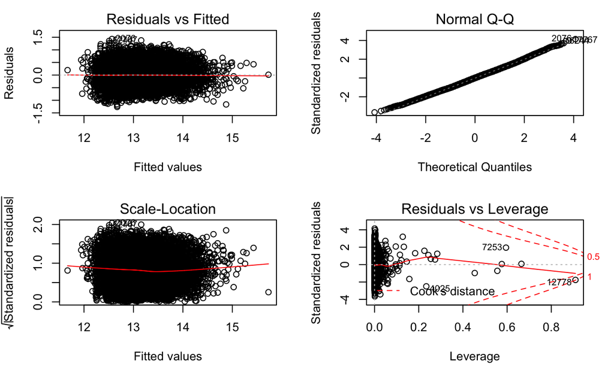

```r
par(mfrow = c(2,2))
plot(house.fit1)
```

### Step 6.3 : Improving the model - log(price) conversion and using only numeric type parameters

#### 1) Adding all the possible relation to the model

fit 2

```r
house.fit2 <- update(house.fit1, ~ . + I(bedrooms^2) + I(bathrooms^2) + I(sqft_living^2) + I(grade^2) + I(sqft_above^2))
summary(house.fit2)
```

```
Call:
lm(formula = price ~ bedrooms + bathrooms + sqft_living + grade +
    sqft_above + I(bedrooms^2) + I(bathrooms^2) + I(sqft_living^2) +
    I(grade^2) + I(sqft_above^2) + bedrooms:bathrooms + bedrooms:sqft_living +
    bathrooms:sqft_living + bedrooms:grade + bathrooms:grade +
    sqft_living:grade + bedrooms:sqft_above + bathrooms:sqft_above +
    sqft_living:sqft_above + grade:sqft_above + bedrooms:bathrooms:sqft_living +
    bedrooms:bathrooms:grade + bedrooms:sqft_living:grade + bathrooms:sqft_living:grade +
    bedrooms:bathrooms:sqft_above + bedrooms:sqft_living:sqft_above +
    bathrooms:sqft_living:sqft_above + bedrooms:grade:sqft_above +
    bathrooms:grade:sqft_above + sqft_living:grade:sqft_above +
    bedrooms:bathrooms:sqft_living:grade + bedrooms:bathrooms:sqft_living:sqft_above +
    bedrooms:bathrooms:grade:sqft_above + bedrooms:sqft_living:grade:sqft_above +
    bathrooms:sqft_living:grade:sqft_above + bedrooms:bathrooms:sqft_living:grade:sqft_above,
    data = house)

Residuals:
     Min       1Q   Median       3Q      Max
-1.33778 -0.24000  0.00412  0.22684  1.43264

Coefficients:
                                                  Estimate Std. Error t value Pr(>|t|)
(Intercept)                                      1.154e+01  2.346e-01  49.202  < 2e-16
bedrooms                                        -2.988e-01  8.473e-02  -3.526 0.000422
bathrooms                                        5.023e-01  2.234e-01   2.249 0.024527
sqft_living                                      5.186e-05  3.622e-04   0.143 0.886147
grade                                            1.068e-01  4.264e-02   2.505 0.012238
sqft_above                                       2.669e-04  4.267e-04   0.626 0.531596
I(bedrooms^2)                                    2.004e-02  2.607e-03   7.685 1.59e-14
I(bathrooms^2)                                   4.356e-02  6.684e-03   6.517 7.35e-11
I(sqft_living^2)                                -1.136e-07  1.234e-08  -9.210  < 2e-16
I(grade^2)                                       8.768e-03  3.035e-03   2.889 0.003874
I(sqft_above^2)                                 -1.182e-07  1.591e-08  -7.432 1.11e-13
bedrooms:bathrooms                              -1.222e-01  5.926e-02  -2.061 0.039268
bedrooms:sqft_living                             9.658e-05  8.794e-05   1.098 0.272135
bathrooms:sqft_living                            1.489e-04  1.344e-04   1.108 0.267742
bedrooms:grade                                   1.963e-02  1.296e-02   1.515 0.129811
bathrooms:grade                                 -8.622e-02  2.830e-02  -3.047 0.002317
sqft_living:grade                                6.238e-05  4.747e-05   1.314 0.188830
bedrooms:sqft_above                              2.741e-05  1.030e-04   0.266 0.790110
```

[output cut: 48 more lines]

```
bedrooms:grade:sqft_above
bathrooms:grade:sqft_above                      *
sqft_living:grade:sqft_above
bedrooms:bathrooms:sqft_living:grade
bedrooms:bathrooms:sqft_living:sqft_above
bedrooms:bathrooms:grade:sqft_above             .
bedrooms:sqft_living:grade:sqft_above
bathrooms:sqft_living:grade:sqft_above
bedrooms:bathrooms:sqft_living:grade:sqft_above
---
Signif. codes:  0 ‘***’ 0.001 ‘**’ 0.01 ‘*’ 0.05 ‘.’ 0.1 ‘ ’ 1

Residual standard error: 0.3435 on 21575 degrees of freedom
Multiple R-squared:  0.5753,    Adjusted R-squared:  0.5746
F-statistic: 811.8 on 36 and 21575 DF,  p-value: < 2.2e-16
```

fit 3

```r
house.fit3 <- update(house.fit2, ~ . + I(bedrooms^3) + I(bathrooms^3) + I(sqft_living^3) + I(grade^3) + I(sqft_above^3))
summary(house.fit3)
```

```
Call:
lm(formula = price ~ bedrooms + bathrooms + sqft_living + grade +
    sqft_above + I(bedrooms^2) + I(bathrooms^2) + I(sqft_living^2) +
    I(grade^2) + I(sqft_above^2) + I(bedrooms^3) + I(bathrooms^3) +
    I(sqft_living^3) + I(grade^3) + I(sqft_above^3) + bedrooms:bathrooms +
    bedrooms:sqft_living + bathrooms:sqft_living + bedrooms:grade +
    bathrooms:grade + sqft_living:grade + bedrooms:sqft_above +
    bathrooms:sqft_above + sqft_living:sqft_above + grade:sqft_above +
    bedrooms:bathrooms:sqft_living + bedrooms:bathrooms:grade +
    bedrooms:sqft_living:grade + bathrooms:sqft_living:grade +
    bedrooms:bathrooms:sqft_above + bedrooms:sqft_living:sqft_above +
    bathrooms:sqft_living:sqft_above + bedrooms:grade:sqft_above +
    bathrooms:grade:sqft_above + sqft_living:grade:sqft_above +
    bedrooms:bathrooms:sqft_living:grade + bedrooms:bathrooms:sqft_living:sqft_above +
    bedrooms:bathrooms:grade:sqft_above + bedrooms:sqft_living:grade:sqft_above +
    bathrooms:sqft_living:grade:sqft_above + bedrooms:bathrooms:sqft_living:grade:sqft_above,
    data = house)

Residuals:
     Min       1Q   Median       3Q      Max
-1.25589 -0.23960  0.00441  0.22727  1.42833

Coefficients:
                                                  Estimate Std. Error t value Pr(>|t|)
(Intercept)                                      1.197e+01  2.887e-01  41.476  < 2e-16
bedrooms                                        -2.639e-01  9.357e-02  -2.820 0.004807
bathrooms                                        6.206e-01  2.444e-01   2.539 0.011118
sqft_living                                      4.076e-04  3.707e-04   1.100 0.271462
grade                                           -1.608e-01  1.222e-01  -1.315 0.188375
sqft_above                                       2.160e-04  4.333e-04   0.499 0.618083
I(bedrooms^2)                                    2.891e-02  8.770e-03   3.296 0.000982
I(bathrooms^2)                                   4.553e-02  2.209e-02   2.062 0.039250
I(sqft_living^2)                                -2.169e-07  2.335e-08  -9.290  < 2e-16
I(grade^2)                                       4.968e-02  1.899e-02   2.617 0.008887
I(sqft_above^2)                                 -1.956e-07  3.053e-08  -6.407 1.52e-10
I(bedrooms^3)                                   -7.685e-04  6.277e-04  -1.224 0.220830
I(bathrooms^3)                                  -6.732e-05  2.759e-03  -0.024 0.980535
I(sqft_living^3)                                 8.428e-12  1.682e-12   5.012 5.42e-07
I(grade^3)                                      -1.729e-03  7.704e-04  -2.244 0.024839
I(sqft_above^3)                                  7.898e-12  2.704e-12   2.921 0.003497
```

[output cut: 60 more lines]

```
bedrooms:grade:sqft_above
bathrooms:grade:sqft_above                      **
sqft_living:grade:sqft_above
bedrooms:bathrooms:sqft_living:grade
bedrooms:bathrooms:sqft_living:sqft_above       *
bedrooms:bathrooms:grade:sqft_above
bedrooms:sqft_living:grade:sqft_above
bathrooms:sqft_living:grade:sqft_above          .
bedrooms:bathrooms:sqft_living:grade:sqft_above *
---
Signif. codes:  0 ‘***’ 0.001 ‘**’ 0.01 ‘*’ 0.05 ‘.’ 0.1 ‘ ’ 1

Residual standard error: 0.3433 on 21570 degrees of freedom
Multiple R-squared:  0.5761,    Adjusted R-squared:  0.5753
F-statistic: 714.9 on 41 and 21570 DF,  p-value: < 2.2e-16
```

fit 4

```r
house.fit4 <- update(house.fit3, ~ . + I(bedrooms^0.5) + I(bathrooms^0.5) + I(sqft_living^0.5) + I(grade^0.5) + I(sqft_above^0.5))
summary(house.fit4)
```

```
Call:
lm(formula = price ~ bedrooms + bathrooms + sqft_living + grade +
    sqft_above + I(bedrooms^2) + I(bathrooms^2) + I(sqft_living^2) +
    I(grade^2) + I(sqft_above^2) + I(bedrooms^3) + I(bathrooms^3) +
    I(sqft_living^3) + I(grade^3) + I(sqft_above^3) + I(bedrooms^0.5) +
    I(bathrooms^0.5) + I(sqft_living^0.5) + I(grade^0.5) + I(sqft_above^0.5) +
    bedrooms:bathrooms + bedrooms:sqft_living + bathrooms:sqft_living +
    bedrooms:grade + bathrooms:grade + sqft_living:grade + bedrooms:sqft_above +
    bathrooms:sqft_above + sqft_living:sqft_above + grade:sqft_above +
    bedrooms:bathrooms:sqft_living + bedrooms:bathrooms:grade +
    bedrooms:sqft_living:grade + bathrooms:sqft_living:grade +
    bedrooms:bathrooms:sqft_above + bedrooms:sqft_living:sqft_above +
    bathrooms:sqft_living:sqft_above + bedrooms:grade:sqft_above +
    bathrooms:grade:sqft_above + sqft_living:grade:sqft_above +
    bedrooms:bathrooms:sqft_living:grade + bedrooms:bathrooms:sqft_living:sqft_above +
    bedrooms:bathrooms:grade:sqft_above + bedrooms:sqft_living:grade:sqft_above +
    bathrooms:sqft_living:grade:sqft_above + bedrooms:bathrooms:sqft_living:grade:sqft_above,
    data = house)

Residuals:
     Min       1Q   Median       3Q      Max
-1.25905 -0.23959  0.00499  0.22729  1.43408

Coefficients:
                                                  Estimate Std. Error t value Pr(>|t|)
(Intercept)                                      1.426e+01  1.907e+00   7.478 7.80e-14
bedrooms                                        -9.121e-01  1.604e-01  -5.687 1.31e-08
bathrooms                                       -1.703e-01  3.755e-01  -0.454 0.650154
sqft_living                                      6.555e-04  7.832e-04   0.837 0.402592
grade                                            7.781e-01  9.200e-01   0.846 0.397673
sqft_above                                       7.509e-04  8.917e-04   0.842 0.399747
I(bedrooms^2)                                    9.462e-02  1.509e-02   6.271 3.64e-10
I(bathrooms^2)                                   1.652e-01  3.874e-02   4.264 2.01e-05
I(sqft_living^2)                                -2.210e-07  4.566e-08  -4.841 1.30e-06
I(grade^2)                                       1.575e-02  4.744e-02   0.332 0.739883
I(sqft_above^2)                                 -2.356e-07  5.803e-08  -4.059 4.95e-05
I(bedrooms^3)                                   -4.098e-03  8.738e-04  -4.689 2.76e-06
I(bathrooms^3)                                  -1.021e-02  3.717e-03  -2.748 0.005997
I(sqft_living^3)                                 8.514e-12  2.407e-12   3.537 0.000405
I(grade^3)                                      -1.058e-03  1.420e-03  -0.745 0.456467
```

[output cut: 71 more lines]

```
bedrooms:grade:sqft_above
bathrooms:grade:sqft_above                      *
sqft_living:grade:sqft_above
bedrooms:bathrooms:sqft_living:grade
bedrooms:bathrooms:sqft_living:sqft_above       .
bedrooms:bathrooms:grade:sqft_above
bedrooms:sqft_living:grade:sqft_above
bathrooms:sqft_living:grade:sqft_above
bedrooms:bathrooms:sqft_living:grade:sqft_above
---
Signif. codes:  0 ‘***’ 0.001 ‘**’ 0.01 ‘*’ 0.05 ‘.’ 0.1 ‘ ’ 1

Residual standard error: 0.3428 on 21565 degrees of freedom
Multiple R-squared:  0.5772,    Adjusted R-squared:  0.5763
F-statistic:   640 on 46 and 21565 DF,  p-value: < 2.2e-16
```

```r
house.fit5 <- step(house.fit4)
```

```
Start:  AIC=-46224.9
price ~ bedrooms + bathrooms + sqft_living + grade + sqft_above +
    I(bedrooms^2) + I(bathrooms^2) + I(sqft_living^2) + I(grade^2) +
    I(sqft_above^2) + I(bedrooms^3) + I(bathrooms^3) + I(sqft_living^3) +
    I(grade^3) + I(sqft_above^3) + I(bedrooms^0.5) + I(bathrooms^0.5) +
    I(sqft_living^0.5) + I(grade^0.5) + I(sqft_above^0.5) + bedrooms:bathrooms +
    bedrooms:sqft_living + bathrooms:sqft_living + bedrooms:grade +
    bathrooms:grade + sqft_living:grade + bedrooms:sqft_above +
    bathrooms:sqft_above + sqft_living:sqft_above + grade:sqft_above +
    bedrooms:bathrooms:sqft_living + bedrooms:bathrooms:grade +
    bedrooms:sqft_living:grade + bathrooms:sqft_living:grade +
    bedrooms:bathrooms:sqft_above + bedrooms:sqft_living:sqft_above +
    bathrooms:sqft_living:sqft_above + bedrooms:grade:sqft_above +
    bathrooms:grade:sqft_above + sqft_living:grade:sqft_above +
    bedrooms:bathrooms:sqft_living:grade + bedrooms:bathrooms:sqft_living:sqft_above +
    bedrooms:bathrooms:grade:sqft_above + bedrooms:sqft_living:grade:sqft_above +
    bathrooms:sqft_living:grade:sqft_above + bedrooms:bathrooms:sqft_living:grade:sqft_above

                                                  Df Sum of Sq    RSS    AIC
- I(sqft_living^0.5)                               1    0.0093 2534.6 -46227
- I(grade^2)                                       1    0.0130 2534.6 -46227
- I(grade^3)                                       1    0.0652 2534.7 -46226
- I(sqft_above^0.5)                                1    0.0855 2534.7 -46226
- I(grade^0.5)                                     1    0.1766 2534.8 -46225
<none>                                                         2534.6 -46225
- bedrooms:bathrooms:sqft_living:grade:sqft_above  1    0.2852 2534.9 -46224
- I(sqft_above^3)                                  1    0.8195 2535.4 -46220
- I(bathrooms^3)                                   1    0.8877 2535.5 -46219
- I(bathrooms^0.5)                                 1    1.0502 2535.7 -46218
- I(sqft_living^3)                                 1    1.4706 2536.1 -46214
- I(sqft_above^2)                                  1    1.9363 2536.6 -46210
- I(bathrooms^2)                                   1    2.1374 2536.8 -46209
- I(bedrooms^3)                                    1    2.5847 2537.2 -46205
- I(bedrooms^0.5)                                  1    2.6253 2537.2 -46205
- I(sqft_living^2)                                 1    2.7539 2537.4 -46203
- I(bedrooms^2)                                    1    4.6228 2539.2 -46188

Step:  AIC=-46226.82
price ~ bedrooms + bathrooms + sqft_living + grade + sqft_above +
    I(bedrooms^2) + I(bathrooms^2) + I(sqft_living^2) + I(grade^2) +
```

[output cut: 460 more lines]

```
- I(grade^3)                        1    1.0168 2536.8 -46237
- I(bathrooms^3)                    1    1.0375 2536.8 -46237
- I(sqft_above^3)                   1    1.1028 2536.8 -46236
- I(bathrooms^0.5)                  1    1.2293 2537.0 -46235
- bathrooms:sqft_living:sqft_above  1    1.9929 2537.7 -46228
- sqft_living:grade:sqft_above      1    2.2561 2538.0 -46226
- I(bathrooms^2)                    1    2.5595 2538.3 -46224
- I(bedrooms^0.5)                   1    2.6484 2538.4 -46223
- I(bedrooms^3)                     1    2.8359 2538.6 -46221
- I(grade^0.5)                      1    2.9839 2538.7 -46220
- I(sqft_living^3)                  1    3.3160 2539.1 -46217
- bathrooms:grade:sqft_above        1    4.5167 2540.3 -46207
- I(bedrooms^2)                     1    5.0270 2540.8 -46203
- I(sqft_above^2)                   1    5.9609 2541.7 -46195
- I(sqft_living^2)                  1   11.7208 2547.5 -46146
```

```r
summary(house.fit5)
```

```
Call:
lm(formula = price ~ bedrooms + bathrooms + sqft_living + grade +
    sqft_above + I(bedrooms^2) + I(bathrooms^2) + I(sqft_living^2) +
    I(sqft_above^2) + I(bedrooms^3) + I(bathrooms^3) + I(sqft_living^3) +
    I(grade^3) + I(sqft_above^3) + I(bedrooms^0.5) + I(bathrooms^0.5) +
    I(grade^0.5) + bedrooms:bathrooms + bedrooms:sqft_living +
    bathrooms:sqft_living + bedrooms:grade + bathrooms:grade +
    sqft_living:grade + bedrooms:sqft_above + bathrooms:sqft_above +
    sqft_living:sqft_above + grade:sqft_above + bedrooms:bathrooms:sqft_living +
    bedrooms:bathrooms:sqft_above + bathrooms:sqft_living:sqft_above +
    bathrooms:grade:sqft_above + sqft_living:grade:sqft_above,
    data = house)

Residuals:
     Min       1Q   Median       3Q      Max
-1.27715 -0.23949  0.00509  0.22722  1.43122

Coefficients:
                                   Estimate Std. Error t value Pr(>|t|)
(Intercept)                       1.486e+01  8.452e-01  17.584  < 2e-16 ***
bedrooms                         -8.647e-01  1.246e-01  -6.938 4.10e-12 ***
bathrooms                        -3.195e-01  2.218e-01  -1.441  0.14973
sqft_living                       2.677e-04  9.256e-05   2.892  0.00383 **
grade                             1.171e+00  1.949e-01   6.009 1.89e-09 ***
sqft_above                        2.628e-04  9.840e-05   2.671  0.00757 **
I(bedrooms^2)                     9.484e-02  1.450e-02   6.541 6.26e-11 ***
I(bathrooms^2)                    1.597e-01  3.421e-02   4.667 3.07e-06 ***
I(sqft_living^2)                 -1.972e-07  1.975e-08  -9.987  < 2e-16 ***
I(sqft_above^2)                  -1.770e-07  2.485e-08  -7.122 1.09e-12 ***
I(bedrooms^3)                    -4.082e-03  8.309e-04  -4.913 9.06e-07 ***
I(bathrooms^3)                   -9.309e-03  3.133e-03  -2.971  0.00297 **
I(sqft_living^3)                  6.878e-12  1.295e-12   5.312 1.09e-07 ***
I(grade^3)                       -6.566e-04  2.232e-04  -2.942  0.00327 **
I(sqft_above^3)                   6.187e-12  2.020e-12   3.063  0.00219 **
I(bedrooms^0.5)                   1.019e+00  2.147e-01   4.747 2.07e-06 ***
I(bathrooms^0.5)                  1.001e+00  3.095e-01   3.234  0.00122 **
I(grade^0.5)                     -4.122e+00  8.180e-01  -5.039 4.72e-07 ***
bedrooms:bathrooms               -7.234e-03  9.490e-03  -0.762  0.44589
bedrooms:sqft_living             -7.325e-06  1.720e-05  -0.426  0.67025
bathrooms:sqft_living             1.361e-04  2.794e-05   4.871 1.12e-06 ***
bedrooms:grade                    1.100e-02  4.760e-03   2.312  0.02080 *
bathrooms:grade                  -8.246e-02  1.350e-02  -6.110 1.01e-09 ***
sqft_living:grade                 3.264e-05  1.208e-05   2.702  0.00690 **
bedrooms:sqft_above               1.851e-06  1.952e-05   0.095  0.92446
bathrooms:sqft_above             -3.248e-04  4.819e-05  -6.741 1.62e-11 ***
sqft_living:sqft_above            4.278e-07  4.682e-08   9.138  < 2e-16 ***
grade:sqft_above                 -5.266e-05  1.187e-05  -4.436 9.20e-06 ***
bedrooms:bathrooms:sqft_living   -1.569e-05  5.607e-06  -2.798  0.00515 **
bedrooms:bathrooms:sqft_above     1.577e-05  6.859e-06   2.299  0.02150 *
bathrooms:sqft_living:sqft_above -1.936e-08  4.701e-09  -4.118 3.83e-05 ***
bathrooms:grade:sqft_above        3.112e-05  5.019e-06   6.200 5.76e-10 ***
sqft_living:grade:sqft_above     -1.404e-08  3.205e-09  -4.382 1.18e-05 ***
---
Signif. codes:  0 ‘***’ 0.001 ‘**’ 0.01 ‘*’ 0.05 ‘.’ 0.1 ‘ ’ 1

Residual standard error: 0.3428 on 21579 degrees of freedom
Multiple R-squared:  0.577, Adjusted R-squared:  0.5764
F-statistic: 919.9 on 32 and 21579 DF,  p-value: < 2.2e-16
```

fit 6 : removing non - significant coefficients manually

```r
house.fit6 <- update(house.fit5, ~ . - bedrooms:sqft_above - bedrooms:sqft_living - bedrooms:bathrooms)
summary(house.fit6)
```

```
Call:
lm(formula = price ~ bedrooms + bathrooms + sqft_living + grade +
    sqft_above + I(bedrooms^2) + I(bathrooms^2) + I(sqft_living^2) +
    I(sqft_above^2) + I(bedrooms^3) + I(bathrooms^3) + I(sqft_living^3) +
    I(grade^3) + I(sqft_above^3) + I(bedrooms^0.5) + I(bathrooms^0.5) +
    I(grade^0.5) + bathrooms:sqft_living + bedrooms:grade + bathrooms:grade +
    sqft_living:grade + bathrooms:sqft_above + sqft_living:sqft_above +
    grade:sqft_above + bedrooms:bathrooms:sqft_living + bedrooms:bathrooms:sqft_above +
    bathrooms:sqft_living:sqft_above + bathrooms:grade:sqft_above +
    sqft_living:grade:sqft_above, data = house)

Residuals:
     Min       1Q   Median       3Q      Max
-1.27917 -0.23935  0.00519  0.22747  1.43123

Coefficients:
                                   Estimate Std. Error t value Pr(>|t|)
(Intercept)                       1.484e+01  8.434e-01  17.592  < 2e-16 ***
bedrooms                         -8.459e-01  1.202e-01  -7.037 2.02e-12 ***
bathrooms                        -3.563e-01  2.141e-01  -1.665 0.095988 .
sqft_living                       2.495e-04  7.701e-05   3.240 0.001199 **
grade                             1.167e+00  1.942e-01   6.007 1.92e-09 ***
sqft_above                        2.707e-04  7.115e-05   3.804 0.000143 ***
I(bedrooms^2)                     9.066e-02  1.334e-02   6.794 1.12e-11 ***
I(bathrooms^2)                    1.596e-01  3.347e-02   4.769 1.86e-06 ***
I(sqft_living^2)                 -1.978e-07  1.873e-08 -10.558  < 2e-16 ***
I(sqft_above^2)                  -1.752e-07  2.423e-08  -7.232 4.93e-13 ***
I(bedrooms^3)                    -3.870e-03  7.814e-04  -4.952 7.40e-07 ***
I(bathrooms^3)                   -9.183e-03  3.003e-03  -3.058 0.002232 **
I(sqft_living^3)                  6.915e-12  1.230e-12   5.621 1.92e-08 ***
I(grade^3)                       -6.586e-04  2.227e-04  -2.957 0.003105 **
I(sqft_above^3)                   5.895e-12  1.922e-12   3.067 0.002164 **
I(bedrooms^0.5)                   9.919e-01  2.105e-01   4.713 2.46e-06 ***
I(bathrooms^0.5)                  1.028e+00  3.023e-01   3.401 0.000673 ***
I(grade^0.5)                     -4.093e+00  8.139e-01  -5.028 4.99e-07 ***
bathrooms:sqft_living             1.404e-04  1.929e-05   7.280 3.46e-13 ***
bedrooms:grade                    9.865e-03  4.200e-03   2.349 0.018845 *
bathrooms:grade                  -8.105e-02  1.337e-02  -6.064 1.35e-09 ***
sqft_living:grade                 3.290e-05  1.195e-05   2.753 0.005917 **
bathrooms:sqft_above             -3.287e-04  4.006e-05  -8.207 2.40e-16 ***
sqft_living:sqft_above            4.255e-07  4.670e-08   9.110  < 2e-16 ***
grade:sqft_above                 -5.234e-05  1.180e-05  -4.436 9.20e-06 ***
bedrooms:bathrooms:sqft_living   -1.795e-05  2.416e-06  -7.432 1.11e-13 ***
bedrooms:bathrooms:sqft_above     1.626e-05  2.796e-06   5.816 6.11e-09 ***
bathrooms:sqft_living:sqft_above -1.835e-08  4.489e-09  -4.088 4.37e-05 ***
bathrooms:grade:sqft_above        3.092e-05  4.999e-06   6.186 6.27e-10 ***
sqft_living:grade:sqft_above     -1.398e-08  3.203e-09  -4.365 1.28e-05 ***
---
Signif. codes:  0 ‘***’ 0.001 ‘**’ 0.01 ‘*’ 0.05 ‘.’ 0.1 ‘ ’ 1

Residual standard error: 0.3428 on 21582 degrees of freedom
Multiple R-squared:  0.577, Adjusted R-squared:  0.5764
F-statistic:  1015 on 29 and 21582 DF,  p-value: < 2.2e-16
```

```r
house.fit7 <- update(house.fit6, ~ . - bathrooms)
summary(house.fit7)
```

```
Call:
lm(formula = price ~ bedrooms + sqft_living + grade + sqft_above +
    I(bedrooms^2) + I(bathrooms^2) + I(sqft_living^2) + I(sqft_above^2) +
    I(bedrooms^3) + I(bathrooms^3) + I(sqft_living^3) + I(grade^3) +
    I(sqft_above^3) + I(bedrooms^0.5) + I(bathrooms^0.5) + I(grade^0.5) +
    bathrooms:sqft_living + bedrooms:grade + bathrooms:grade +
    sqft_living:grade + bathrooms:sqft_above + sqft_living:sqft_above +
    grade:sqft_above + bedrooms:bathrooms:sqft_living + bedrooms:bathrooms:sqft_above +
    bathrooms:sqft_living:sqft_above + bathrooms:grade:sqft_above +
    sqft_living:grade:sqft_above, data = house)

Residuals:
     Min       1Q   Median       3Q      Max
-1.28967 -0.23949  0.00514  0.22730  1.43077

Coefficients:
                                   Estimate Std. Error t value Pr(>|t|)
(Intercept)                       1.475e+01  8.418e-01  17.522  < 2e-16 ***
bedrooms                         -9.301e-01  1.090e-01  -8.529  < 2e-16 ***
sqft_living                       2.074e-04  7.274e-05   2.851 0.004362 **
grade                             1.139e+00  1.935e-01   5.885 4.04e-09 ***
sqft_above                        2.875e-04  7.043e-05   4.082 4.48e-05 ***
I(bedrooms^2)                     9.738e-02  1.272e-02   7.657 1.99e-14 ***
I(bathrooms^2)                    1.150e-01  2.003e-02   5.740 9.61e-09 ***
I(sqft_living^2)                 -2.056e-07  1.813e-08 -11.345  < 2e-16 ***
I(sqft_above^2)                  -1.849e-07  2.351e-08  -7.868 3.78e-15 ***
I(bedrooms^3)                    -4.163e-03  7.613e-04  -5.468 4.59e-08 ***
I(bathrooms^3)                   -5.729e-03  2.171e-03  -2.639 0.008329 **
I(sqft_living^3)                  7.541e-12  1.172e-12   6.436 1.25e-10 ***
I(grade^3)                       -6.110e-04  2.208e-04  -2.767 0.005669 **
I(sqft_above^3)                   6.728e-12  1.856e-12   3.625 0.000289 ***
I(bedrooms^0.5)                   1.154e+00  1.867e-01   6.178 6.59e-10 ***
I(bathrooms^0.5)                  5.685e-01  1.232e-01   4.615 3.95e-06 ***
I(grade^0.5)                     -3.946e+00  8.092e-01  -4.877 1.09e-06 ***
sqft_living:bathrooms             1.471e-04  1.887e-05   7.800 6.49e-15 ***
bedrooms:grade                    1.057e-02  4.179e-03   2.529 0.011451 *
grade:bathrooms                  -9.019e-02  1.218e-02  -7.402 1.39e-13 ***
sqft_living:grade                 3.779e-05  1.159e-05   3.261 0.001110 **
sqft_above:bathrooms             -3.475e-04  3.845e-05  -9.037  < 2e-16 ***
sqft_living:sqft_above            4.571e-07  4.268e-08  10.710  < 2e-16 ***
grade:sqft_above                 -5.600e-05  1.159e-05  -4.831 1.37e-06 ***
bedrooms:sqft_living:bathrooms   -1.793e-05  2.416e-06  -7.421 1.21e-13 ***
bedrooms:sqft_above:bathrooms     1.598e-05  2.790e-06   5.725 1.05e-08 ***
sqft_living:sqft_above:bathrooms -2.140e-08  4.097e-09  -5.225 1.76e-07 ***
grade:sqft_above:bathrooms        3.449e-05  4.516e-06   7.639 2.28e-14 ***
sqft_living:grade:sqft_above     -1.603e-08  2.957e-09  -5.422 5.96e-08 ***
---
Signif. codes:  0 ‘***’ 0.001 ‘**’ 0.01 ‘*’ 0.05 ‘.’ 0.1 ‘ ’ 1

Residual standard error: 0.3428 on 21583 degrees of freedom
Multiple R-squared:  0.577, Adjusted R-squared:  0.5764
F-statistic:  1051 on 28 and 21583 DF,  p-value: < 2.2e-16
```